# BankCamp

Group 4: Andrew Rizk, Dominik Thausing, Andrea Salvati, Aksel Huseb?, Manuel Ehmann, Daan Pelt, Martin Da Costa Louzada

3 June 2019

### Bank Marketing

Abstract: The data is related with direct marketing campaigns (phone calls) of a Portuguese banking institution. The classification goal is to predict if the client will subscribe a term deposit (variable y).

Data Set Information: The data is related with direct marketing campaigns of a Portuguese banking institution. The marketing campaigns were based on phone calls. Often, more than one contact to the same client was required, in order to access if the product (bank term deposit) would be (‘yes’) or not (‘no’) subscribed.

#### Attribute Information:

##### related with the last contact of the current campaign:

8 - contact: contact communication type (categorical: ‘cellular’,‘telephone’) 9 - month: last contact month of year (categorical: ‘jan’, ‘feb’, ‘mar’, …, ‘nov’, ‘dec’) 10 - day_of_week: last contact day of the week (categorical: ‘mon’,‘tue’,‘wed’,‘thu’,‘fri’) 11 - duration: last contact duration, in seconds (numeric). Important note: this attribute highly affects the output target (e.g., if duration=0 then y=‘no’). Yet, the duration is not known before a call is performed. Also, after the end of the call y is obviously known. Thus, this input should only be included for benchmark purposes and should be discarded if the intention is to have a realistic predictive model.

##### other attributes:

12 - campaign: number of contacts performed during this campaign and for this client (numeric, includes last contact) 13 - pdays: number of days that passed by after the client was last contacted from a previous campaign (numeric; 999 means client was not previously contacted) 14 - previous: number of contacts performed before this campaign and for this client (numeric) 15 - poutcome: outcome of the previous marketing campaign (categorical: ‘failure’,‘nonexistent’,‘success’)

##### Output variable (desired target):

21 - y - has the client subscribed a term deposit? (binary: ‘yes’,‘no’)

##### Source:

Dataset from : http://archive.ics.uci.edu/ml/datasets/Bank+Marketing#

#### Load Libraries

```r
library(data.table)
library(corrplot)
library(ggplot2)
library(dplyr)
library(png)
library(knitr)
library(moments)
library(e1071)
library(glmnet)
library(caret)
library(lubridate)
library(VIM)
library(ggmap)
library(xgboost)
library(mlr)
library(adabag)
library(party)
library(maps)
library(ggthemes)
library(DT)
library(leaflet)
library(missForest)
library(RColorBrewer)
library(DiagrammeR)
library(ROCR)
library(pROC)
library(plotROC)
library(nnet)
library(caretEnsemble)
library(mlbench)
library(DataExplorer)
library(outliers)
library(MLmetrics)
library(dummies)
library(DMwR)
```

#### Load Datasets

```r
bank_train <- read.csv("BankCamp_train.csv", header = T)
bank_test <- read.csv("BankCamp_test.csv", header = T)

# Since the test set has no target column, we will create one before combining both
bank_test$y <- NA

# We will add a column with a factor of train/test to help with the dataset splitting further
bank_train$train_test <- "train"
bank_test$train_test <- "test"

# Combining both datasets
bank_dataset <- rbind(bank_train, bank_test)
cat("The train set has ", dim(bank_train)[1], "rows and ", dim(bank_train)[2], "columns, ")
```

```
## The train set has  36168 rows and  18 columns,
```

```r
cat("The test set has ", dim(bank_test)[1], "rows and ", dim(bank_test)[2], "columns, ")
```

```
## The test set has  9043 rows and  18 columns,
```

```r
cat("The combined dataset has ", dim(bank_dataset)[1], "rows and ", dim(bank_dataset)[2], "columns")
```

```
## The combined dataset has  45211 rows and  18 columns
```

#### NA Discovery

We need to clean NA values in all the columns and fill the empty cells with proper judgements based on each variable’s condition. First, we explore which columns have missing values.

[figure not shown]

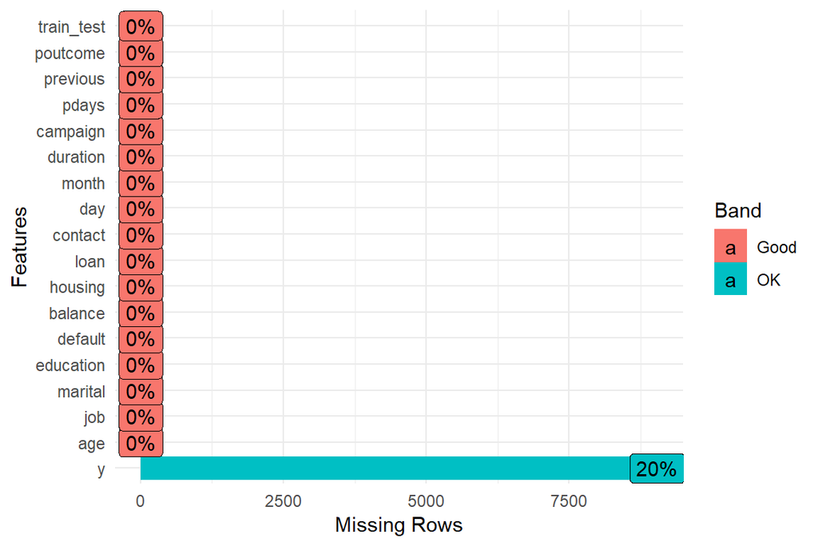

```r
# Visualizing Missing Data
plot_missing(bank_dataset) + theme_minimal()
```

```r
na.cols <- which(colSums(is.na(bank_dataset)) > 0)
paste('There are', length(na.cols), 'columns with missing values')
```

```
## [1] "There are 1 columns with missing values"
```

```r
sort(colSums(sapply(bank_dataset[na.cols], is.na)), decreasing = TRUE)
```

```
##    y
## 9043
```

Therefore no missing values are present in the dataset and we can continue with feature engineering

#### Data Structure

Now we will check the structure of the dataset.

```r
# visualizing the dataset to know the structure and components of each variable
str(bank_dataset)
```

```
## 'data.frame':    45211 obs. of  18 variables:
##  $ age       : int  50 47 56 36 41 32 26 60 39 55 ...
##  $ job       : Factor w/ 12 levels "admin.","blue-collar",..: 3 10 4 2 5 9 9 2 8 1 ...
##  $ marital   : Factor w/ 3 levels "divorced","married",..: 2 2 2 2 2 3 3 2 1 1 ...
##  $ education : Factor w/ 4 levels "primary","secondary",..: 1 2 1 1 1 3 2 1 2 2 ...
##  $ default   : Factor w/ 2 levels "no","yes": 2 1 1 1 1 1 1 1 1 1 ...
##  $ balance   : int  537 -938 605 4608 362 0 782 193 2140 873 ...
##  $ housing   : Factor w/ 2 levels "no","yes": 2 2 1 2 2 1 1 2 2 2 ...
##  $ loan      : Factor w/ 2 levels "no","yes": 1 1 1 1 1 1 1 1 1 2 ...
##  $ contact   : Factor w/ 3 levels "cellular","telephone",..: 3 3 1 1 1 1 1 2 1 3 ...
##  $ day       : int  20 28 19 14 12 4 29 12 16 3 ...
##  $ month     : Factor w/ 12 levels "apr","aug","dec",..: 7 9 2 9 9 4 5 9 1 7 ...
##  $ duration  : int  11 176 207 284 217 233 297 89 539 131 ...
##  $ campaign  : int  15 2 6 7 3 3 1 2 1 1 ...
##  $ pdays     : int  -1 -1 -1 -1 -1 276 -1 -1 -1 -1 ...
##  $ previous  : int  0 0 0 0 0 2 0 0 0 0 ...
##  $ poutcome  : Factor w/ 4 levels "failure","other",..: 4 4 4 4 4 1 4 4 4 4 ...
##  $ y         : Factor w/ 2 levels "no","yes": 1 1 1 1 1 2 1 1 1 1 ...
##  $ train_test: chr  "train" "train" "train" "train" ...
```

```r
summary(bank_dataset)
```

```
##       age                 job           marital          education
##  Min.   :18.00   blue-collar:9732   divorced: 5207   primary  : 6851
##  1st Qu.:33.00   management :9458   married :27214   secondary:23202
##  Median :39.00   technician :7597   single  :12790   tertiary :13301
##  Mean   :40.94   admin.     :5171                    unknown  : 1857
##  3rd Qu.:48.00   services   :4154
##  Max.   :95.00   retired    :2264
##                  (Other)    :6835
##  default        balance       housing      loan            contact
##  no :44396   Min.   : -8019   no :20081   no :37967   cellular :29285
##  yes:  815   1st Qu.:    72   yes:25130   yes: 7244   telephone: 2906
##              Median :   448                           unknown  :13020
##              Mean   :  1362
##              3rd Qu.:  1428
##              Max.   :102127
##
##       day            month          duration         campaign
##  Min.   : 1.00   may    :13766   Min.   :   0.0   Min.   : 1.000
##  1st Qu.: 8.00   jul    : 6895   1st Qu.: 103.0   1st Qu.: 1.000
##  Median :16.00   aug    : 6247   Median : 180.0   Median : 2.000
##  Mean   :15.81   jun    : 5341   Mean   : 258.2   Mean   : 2.764
##  3rd Qu.:21.00   nov    : 3970   3rd Qu.: 319.0   3rd Qu.: 3.000
##  Max.   :31.00   apr    : 2932   Max.   :4918.0   Max.   :63.000
##                  (Other): 6060
##      pdays          previous           poutcome        y
##  Min.   : -1.0   Min.   :  0.0000   failure: 4901   no  :31973
##  1st Qu.: -1.0   1st Qu.:  0.0000   other  : 1840   yes : 4195
##  Median : -1.0   Median :  0.0000   success: 1511   NA's: 9043
##  Mean   : 40.2   Mean   :  0.5803   unknown:36959
##  3rd Qu.: -1.0   3rd Qu.:  0.0000
##  Max.   :871.0   Max.   :275.0000
##
##   train_test
##  Length:45211
##  Class :character
##  Mode  :character
##
##
##
##
```

#### EDA

```r
# Count of target classes
table(bank_dataset$y)
```

```
##
##    no   yes
## 31973  4195
```

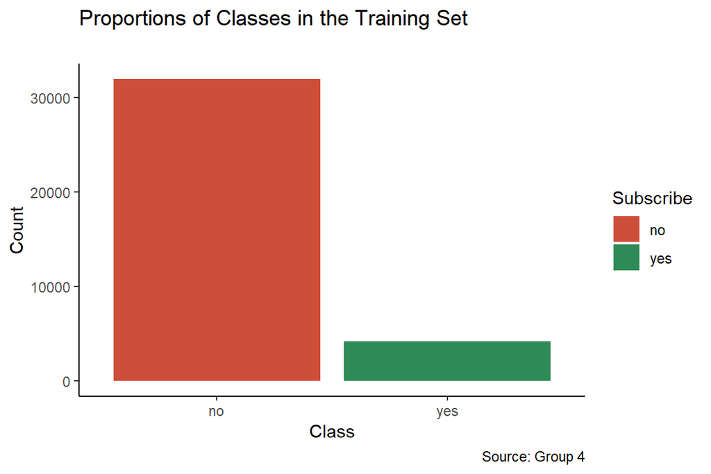

```r
#Determine Class Proportions
class_percentage <- bank_dataset[bank_dataset$train_test == "train",] %>% group_by(y) %>% summarise(count = n(), percentage = round(n()*100/36168,2))

#Barplot of Classes
ggplot(class_percentage, aes(x=y, y=count, label=count, fill = y)) +
  geom_bar(stat='identity') +
  labs(title="Proportions of Classes in the Training Set",subtitle = "",caption = "Source: Group 4",
       x = "Class", y= "Count", fill = "Subscribe") + theme_classic() +
  scale_y_continuous(labels = function(x) format(x, scientific = FALSE)) +
  scale_fill_manual(values = c("tomato3", "seagreen4"))
```

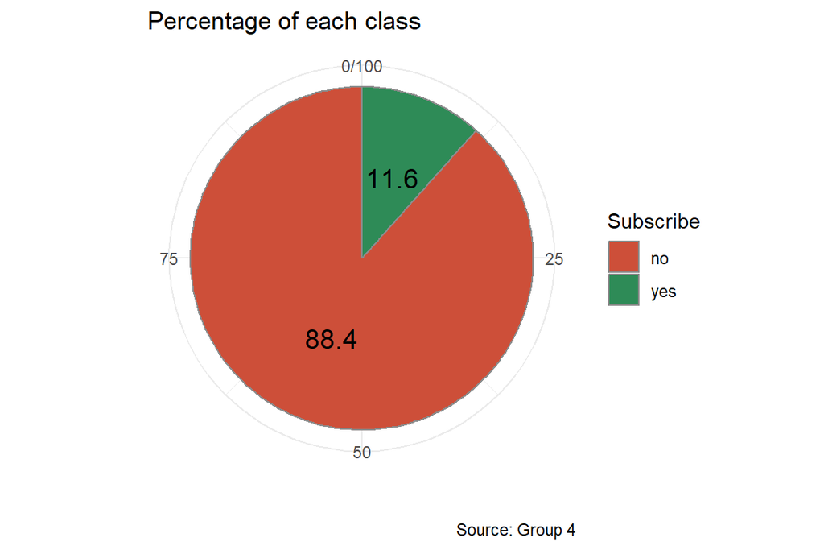

```r
#Pie Chart of Classes
ggplot(class_percentage, aes(x = "", y = percentage, fill = y)) +
  geom_bar(width = 1, stat = "identity", color = "gray55") +
  coord_polar("y", start = 0) +
  geom_text(aes(y = sum(percentage) - cumsum(percentage) + percentage / 2, label = percentage), color = "black", size = 5) +
  theme_minimal() + ggtitle("Percentage of each class") + labs(x="", y="", fill = "Subscribe", caption = "Source: Group 4") + scale_fill_manual(values = c("tomato3", "seagreen4"))
```

```r
# JOB
# Count for each job versus the target variable
table(bank_train$job, bank_train$y)
```

```
##
##                   no  yes
##   admin.        3666  515
##   blue-collar   7289  559
##   entrepreneur  1090   94
##   housemaid      919   90
##   management    6494 1018
##   retired       1416  410
##   self-employed 1120  146
##   services      2984  302
##   student        534  221
##   technician    5398  662
##   unemployed     872  150
##   unknown        191   28
```

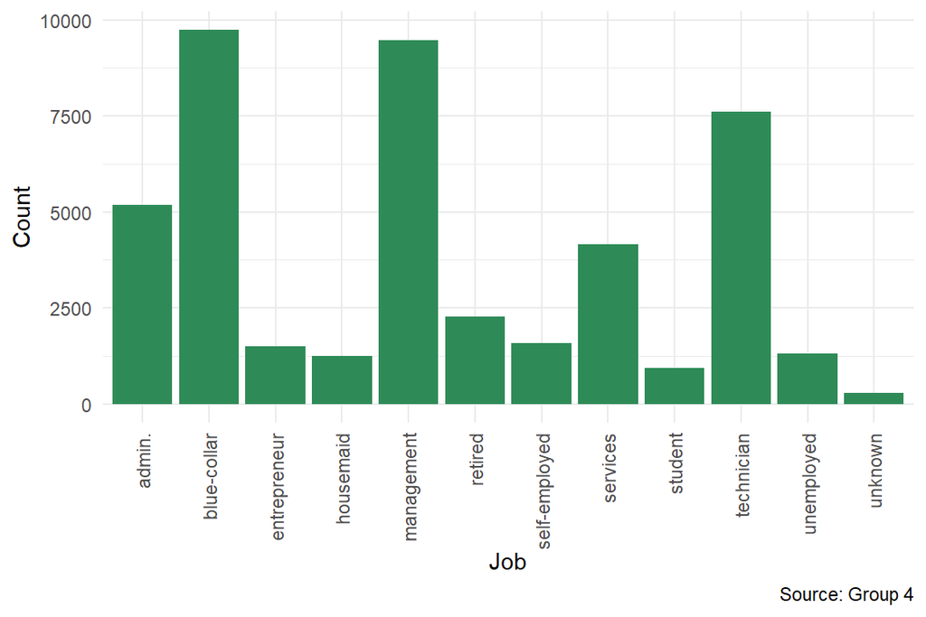

```r
# Count of each category in the whole dataset
ggplot(data = bank_dataset, aes(x = job)) + geom_bar(fill = "seagreen4") + theme_minimal() +
  theme(axis.text.x = element_text(angle = 90, hjust = 1, vjust = 0.5)) + labs(x = "Job", y = "Count", caption = "Source: Group 4")
```

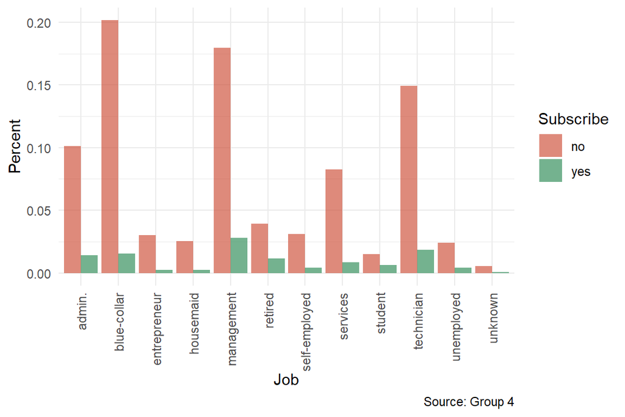

```r
# Probability table
job <- as.data.frame(prop.table(table(bank_train$job, bank_train$y)))
colnames(job) <-  c("job", "y", "perc")

ggplot(data = job, aes(x = job, y = perc, fill = y)) +
  geom_bar(stat = 'identity', position = 'dodge', alpha = 2/3) +xlab("Job")+
    ylab("Percent") + theme_minimal() + theme(axis.text.x = element_text(angle = 90, hjust = 1, vjust = 0.5)) +
  scale_fill_manual(values = c("tomato3", "seagreen4")) + labs(fill = "Subscribe", caption = "Source: Group 4")
```

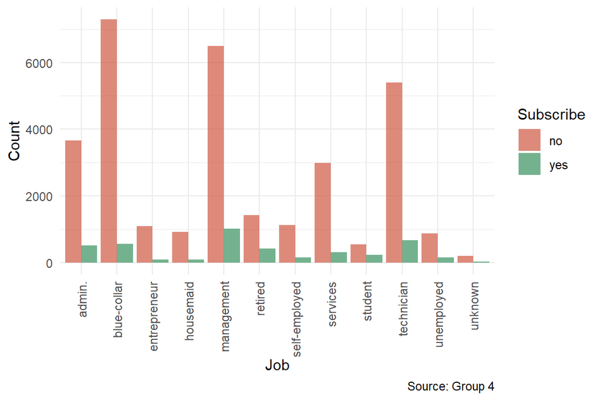

```r
# Using count
job2 <- as.data.frame(table(bank_train$job, bank_train$y))
colnames(job2) <-  c("job", "y", "count")

ggplot(data = job2, aes(x = job, y = count, fill = y)) +
  geom_bar(stat = 'identity', position = 'dodge', alpha = 2/3) +xlab("Job")+
    ylab("Count") + theme_minimal() + theme(axis.text.x = element_text(angle = 90, hjust = 1, vjust = 0.5)) +
  scale_fill_manual(values = c("tomato3", "seagreen4")) + labs(fill = "Subscribe", caption = "Source: Group 4")
```

```r
# Marital Status
# Count for each marital status versus the target variable
table(bank_dataset$marital)
```

```
##
## divorced  married   single
##     5207    27214    12790
```

```r
table(bank_train$marital, bank_train$y)
```

```
##
##               no   yes
##   divorced  3660   488
##   married  19633  2205
##   single    8680  1502
```

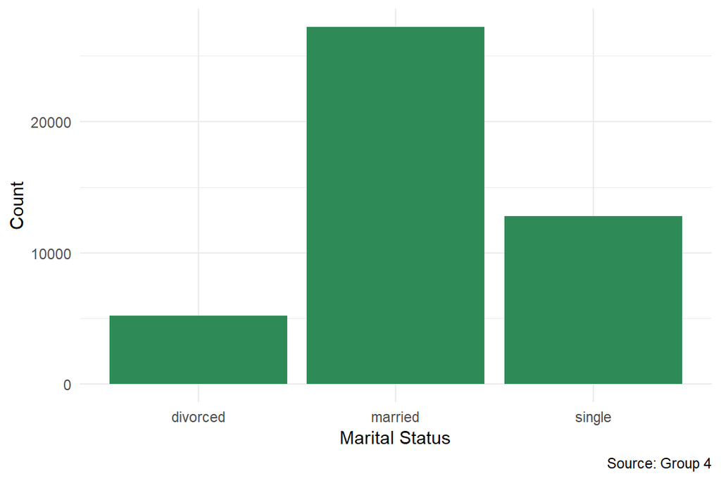

```r
# Count of each category in the whole dataset
ggplot(data = bank_dataset, aes(x = marital)) + geom_bar(fill = "seagreen4") + theme_minimal() + labs(x = "Marital Status", y = "Count", caption = "Source: Group 4")
```

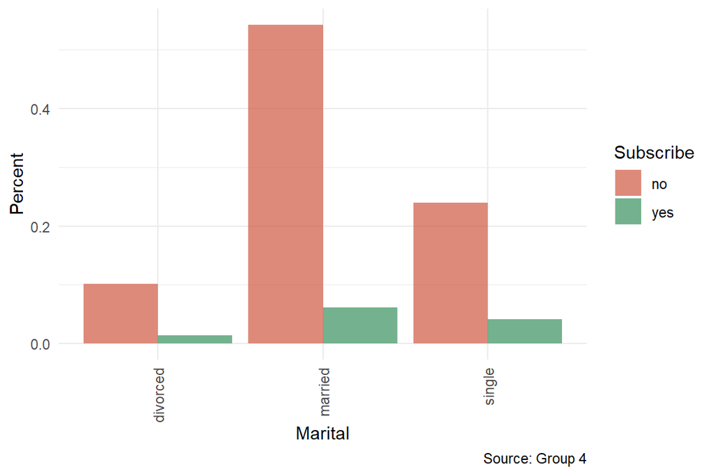

```r
# Probability table
marital <- as.data.frame(prop.table(table(bank_train$marital, bank_train$y)))
colnames(marital) <-  c("marital", "y", "perc")

ggplot(data = marital, aes(x = marital, y = perc, fill = y)) +
  geom_bar(stat = 'identity', position = 'dodge', alpha = 2/3) +xlab("Marital")+
    ylab("Percent") + theme_minimal() + theme(axis.text.x = element_text(angle = 90, hjust = 1, vjust = 0.5)) +
  scale_fill_manual(values = c("tomato3", "seagreen4")) + labs(fill = "Subscribe", caption = "Source: Group 4")
```

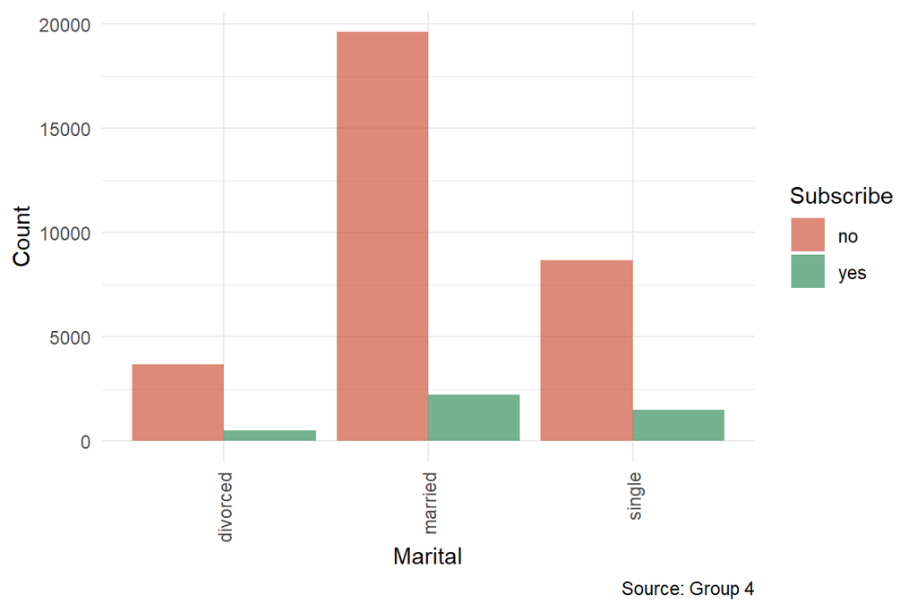

```r
# Using count
marital2 <- as.data.frame(table(bank_train$marital, bank_train$y))
colnames(marital2) <-  c("marital", "y", "count")

ggplot(data = marital2, aes(x = marital, y = count, fill = y)) +
  geom_bar(stat = 'identity', position = 'dodge', alpha = 2/3) +xlab("Marital")+
    ylab("Count") + theme_minimal() + theme(axis.text.x = element_text(angle = 90, hjust = 1, vjust = 0.5)) +
  scale_fill_manual(values = c("tomato3", "seagreen4")) + labs(fill = "Subscribe", caption = "Source: Group 4")
```

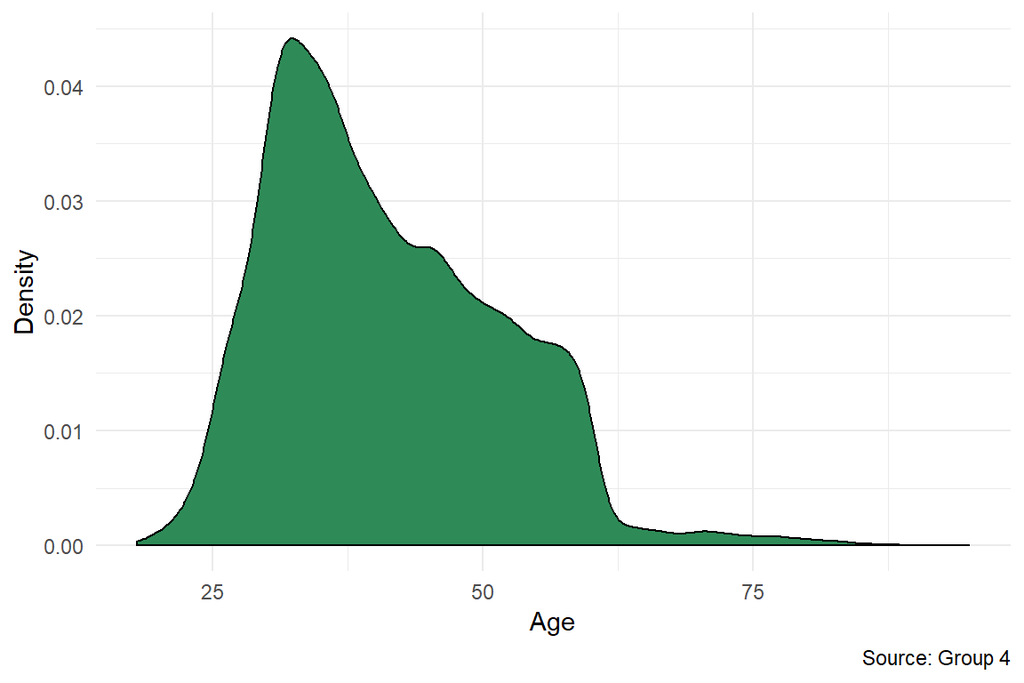

```r
# Age distribution
ggplot(bank_dataset, aes(age)) + geom_density(fill = "seagreen4") + theme_minimal() + labs(x = "Age", y = "Density", caption = "Source: Group 4")
```

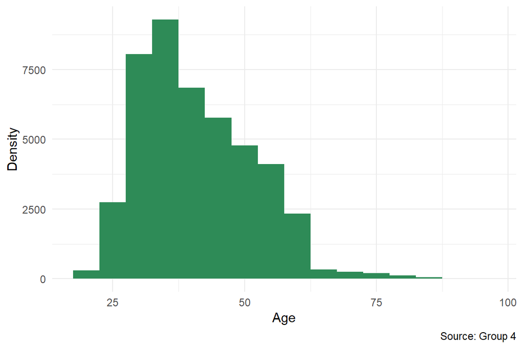

```r
ggplot(bank_dataset, aes(age)) + geom_histogram(fill = "seagreen4", binwidth = 5) + theme_minimal() + labs(x = "Age", y = "Density", caption = "Source: Group 4")
```

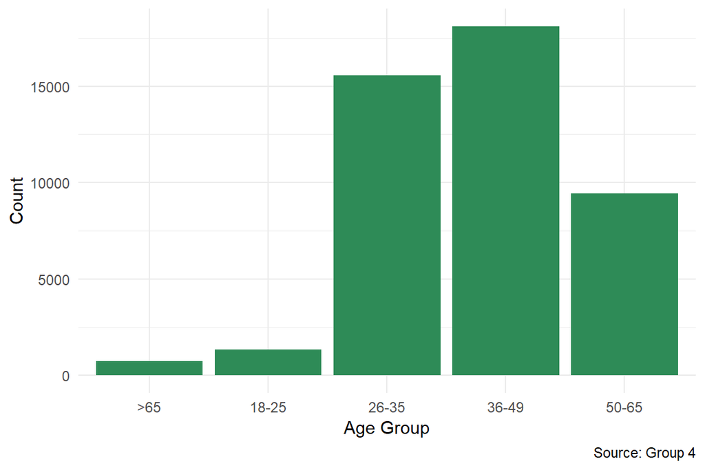

```r
# We will bin the age into age groups and visualize it with subscribtions
bank_dataset <- bank_dataset %>% mutate(age_group = ifelse(age >= 18 & age <= 25, "18-25",
                                                           ifelse(age > 25 & age <= 35, "26-35",
                                                                  ifelse(age > 35 & age < 50, "36-49",
                                                                         ifelse(age >= 50 & age <= 65, "50-65", ">65")))))
# Count of each category in the whole dataset
ggplot(data = bank_dataset, aes(x = age_group)) + geom_bar(fill = "seagreen4") + theme_minimal() + labs(x = "Age Group", y = "Count", caption = "Source: Group 4")
```

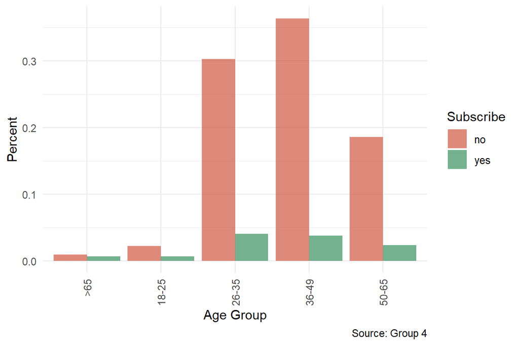

```r
# Probability table
age_group <- as.data.frame(prop.table(table(bank_dataset[bank_dataset$train_test=="train",]$age_group, bank_dataset[bank_dataset$train_test=="train",]$y)))
colnames(age_group) <-  c("age_group", "y", "perc")

ggplot(data = age_group, aes(x = age_group, y = perc, fill = y)) +
  geom_bar(stat = 'identity', position = 'dodge', alpha = 2/3) +xlab("Age Group")+
    ylab("Percent") + theme_minimal() + theme(axis.text.x = element_text(angle = 90, hjust = 1, vjust = 0.5)) +
  scale_fill_manual(values = c("tomato3", "seagreen4")) + labs(fill = "Subscribe", caption = "Source: Group 4")
```

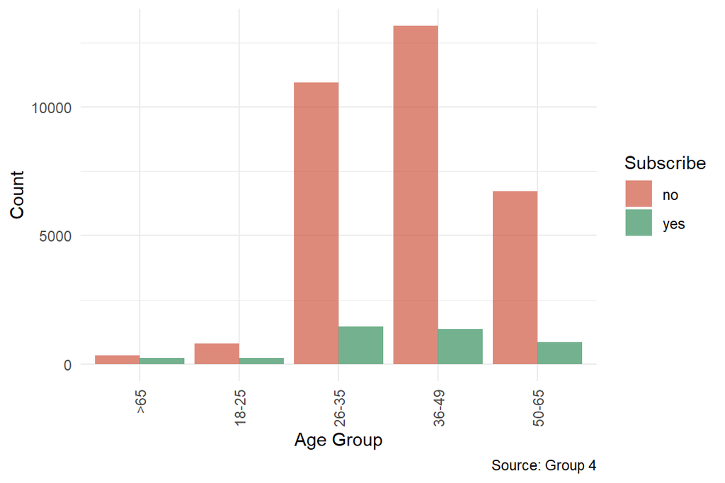

```r
# Using count
age_group2 <- as.data.frame(table(bank_dataset[bank_dataset$train_test=="train",]$age_group, bank_dataset[bank_dataset$train_test=="train",]$y))
colnames(age_group2) <-  c("age_group", "y", "count")

ggplot(data = age_group2, aes(x = age_group, y = count, fill = y)) +
  geom_bar(stat = 'identity', position = 'dodge', alpha = 2/3) +xlab("Age Group")+
    ylab("Count") + theme_minimal() + theme(axis.text.x = element_text(angle = 90, hjust = 1, vjust = 0.5)) +
  scale_fill_manual(values = c("tomato3", "seagreen4")) + labs(fill = "Subscribe", caption = "Source: Group 4")
```

```r
# Education Level
# Count for each educational level versus the target variable
table(bank_dataset$education)
```

```
##
##   primary secondary  tertiary   unknown
##      6851     23202     13301      1857
```

```r
table(bank_dataset[bank_dataset$train_test=="train",]$education, bank_dataset[bank_dataset$train_test=="train",]$y)
```

```
##
##                no   yes
##   primary    5047   470
##   secondary 16614  1943
##   tertiary   9025  1573
##   unknown    1287   209
```

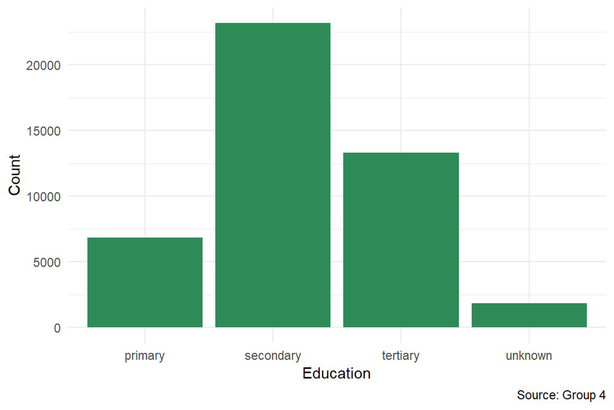

```r
# Count of each category in the whole dataset
ggplot(data = bank_dataset, aes(x = education)) + geom_bar(fill = "seagreen4") + theme_minimal() + labs(x = "Education", y = "Count", caption = "Source: Group 4")
```

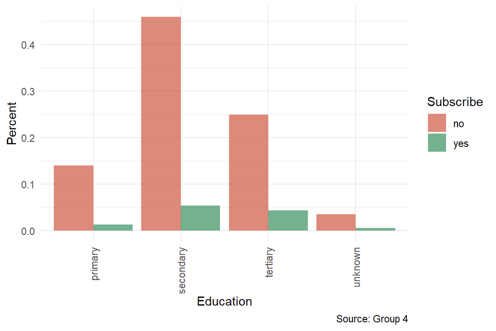

```r
# Probability table
edu <- as.data.frame(prop.table(table(bank_dataset[bank_dataset$train_test=="train",]$education, bank_dataset[bank_dataset$train_test=="train",]$y)))
colnames(edu) <-  c("education", "y", "perc")

ggplot(data = edu, aes(x = education, y = perc, fill = y)) +
  geom_bar(stat = 'identity', position = 'dodge', alpha = 2/3) +xlab("Education")+
    ylab("Percent") + theme_minimal() + theme(axis.text.x = element_text(angle = 90, hjust = 1, vjust = 0.5)) +
  scale_fill_manual(values = c("tomato3", "seagreen4")) + labs(fill = "Subscribe", caption = "Source: Group 4")
```

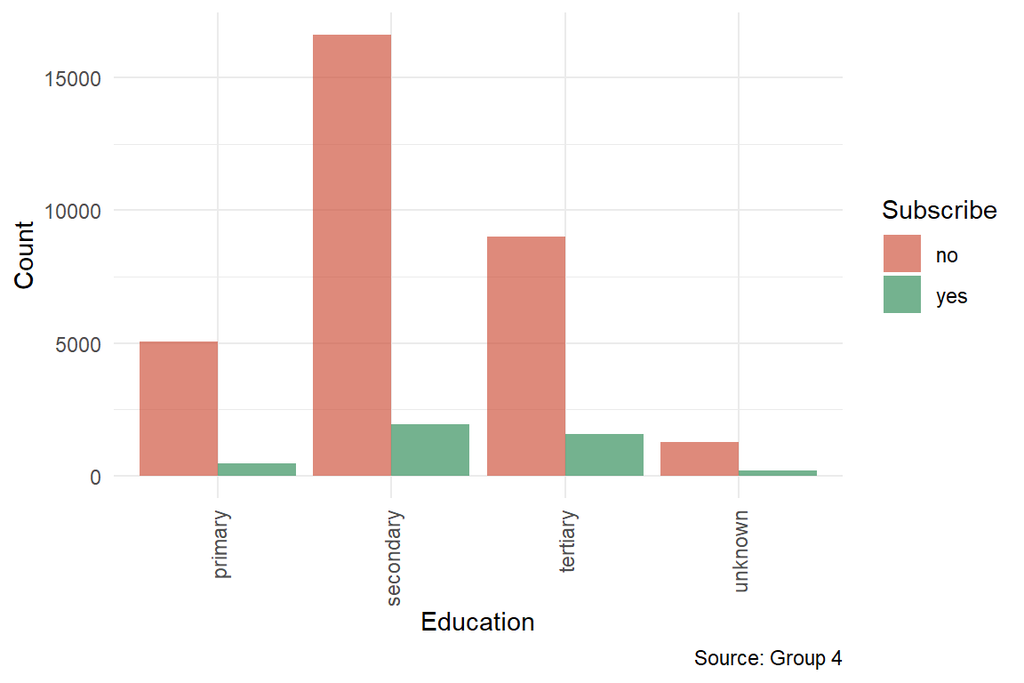

```r
# Using count
edu2 <- as.data.frame(table(bank_dataset[bank_dataset$train_test=="train",]$education, bank_dataset[bank_dataset$train_test=="train",]$y))
colnames(edu2) <-  c("education", "y", "count")

ggplot(data = edu2, aes(x = education, y = count, fill = y)) +
  geom_bar(stat = 'identity', position = 'dodge', alpha = 2/3) +xlab("Education")+
    ylab("Count") + theme_minimal() + theme(axis.text.x = element_text(angle = 90, hjust = 1, vjust = 0.5)) +
  scale_fill_manual(values = c("tomato3", "seagreen4")) + labs(fill = "Subscribe", caption = "Source: Group 4")
```

```r
# Default: has credit in default? (categorical: 'no', 'yes', 'unknown')

table(bank_dataset$default)
```

```
##
##    no   yes
## 44396   815
```

```r
table(bank_dataset[bank_dataset$train_test=="train",]$default, bank_dataset[bank_dataset$train_test=="train",]$y)
```

```
##
##          no   yes
##   no  31362  4147
##   yes   611    48
```

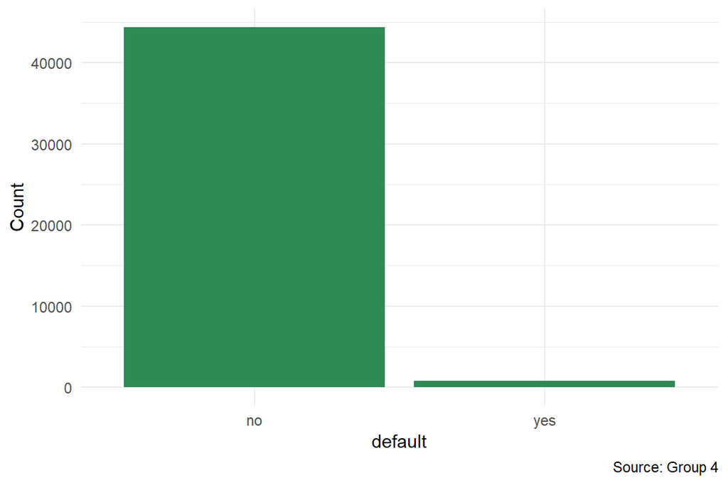

```r
# Count of each category in the whole dataset
ggplot(data = bank_dataset, aes(x = default)) + geom_bar(fill = "seagreen4") + theme_minimal() + labs(x = "default", y = "Count", caption = "Source: Group 4")
```

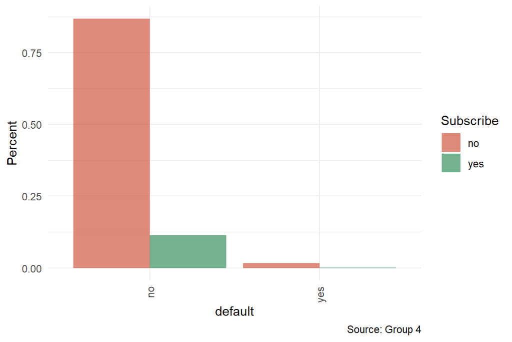

```r
# Probability table
default <- as.data.frame(prop.table(table(bank_dataset[bank_dataset$train_test=="train",]$default, bank_dataset[bank_dataset$train_test=="train",]$y)))
colnames(default) <-  c("default", "y", "perc")

ggplot(data = default, aes(x = default, y = perc, fill = y)) +
  geom_bar(stat = 'identity', position = 'dodge', alpha = 2/3) +xlab("default")+
    ylab("Percent") + theme_minimal() + theme(axis.text.x = element_text(angle = 90, hjust = 1, vjust = 0.5)) +
  scale_fill_manual(values = c("tomato3", "seagreen4")) + labs(fill = "Subscribe", caption = "Source: Group 4")
```

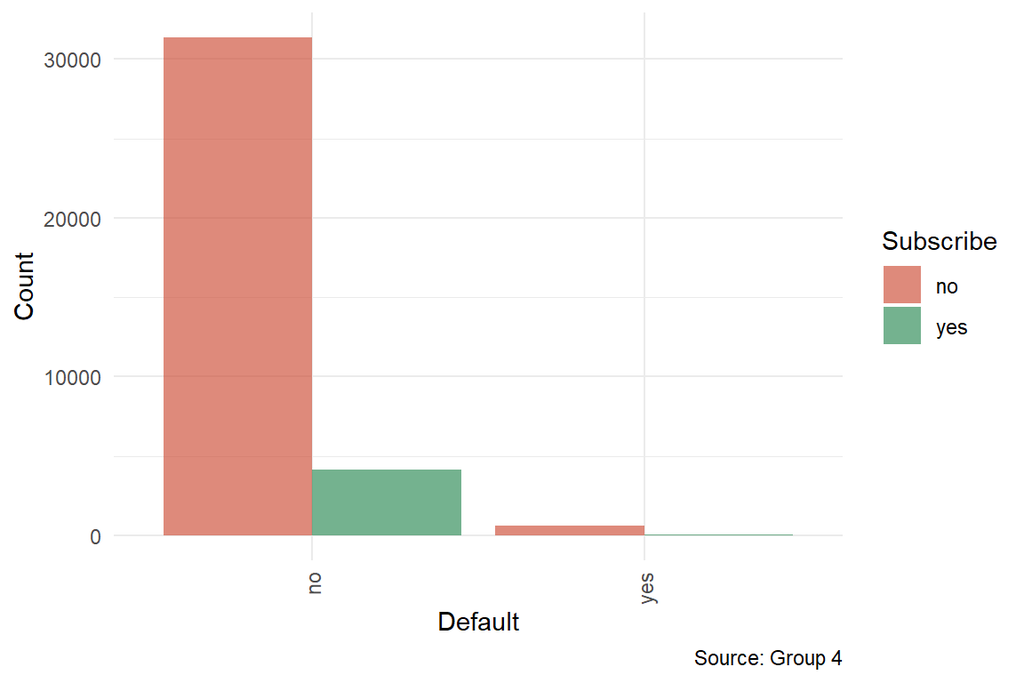

```r
# Using count
default2 <- as.data.frame(table(bank_dataset[bank_dataset$train_test=="train",]$default, bank_dataset[bank_dataset$train_test=="train",]$y))
colnames(default2) <-  c("default", "y", "count")

ggplot(data = default2, aes(x = default, y = count, fill = y)) +
  geom_bar(stat = 'identity', position = 'dodge', alpha = 2/3) +xlab("Default")+
    ylab("Count") + theme_minimal() + theme(axis.text.x = element_text(angle = 90, hjust = 1, vjust = 0.5)) +
  scale_fill_manual(values = c("tomato3", "seagreen4")) + labs(fill = "Subscribe", caption = "Source: Group 4")
```

```r
# Housing: has housing loan? (categorical: 'no', 'yes', 'unknown')

table(bank_dataset$housing)
```

```
##
##    no   yes
## 20081 25130
```

```r
table(bank_dataset[bank_dataset$train_test=="train",]$housing, bank_dataset[bank_dataset$train_test=="train",]$y)
```

```
##
##          no   yes
##   no  13389  2645
##   yes 18584  1550
```

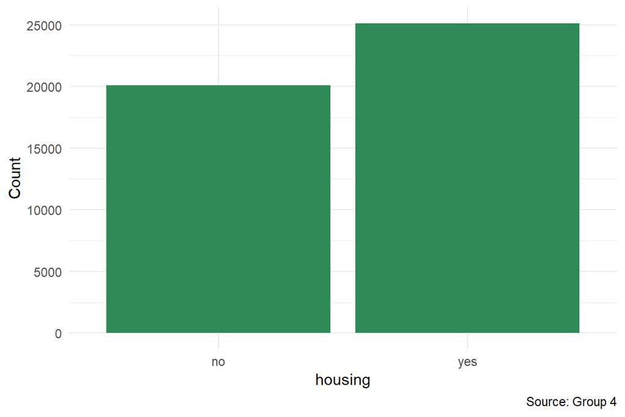

```r
# Count of each category in the whole dataset
ggplot(data = bank_dataset, aes(x = housing)) + geom_bar(fill = "seagreen4") + theme_minimal() + labs(x = "housing", y = "Count", caption = "Source: Group 4")
```

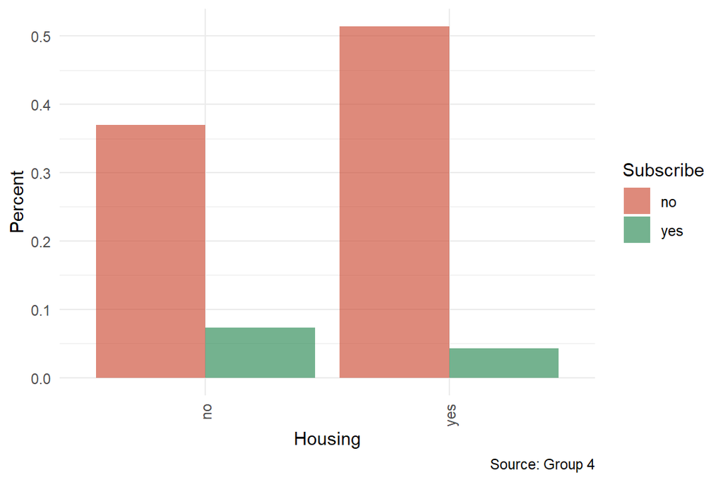

```r
# Probability table
housing <- as.data.frame(prop.table(table(bank_dataset[bank_dataset$train_test=="train",]$housing, bank_dataset[bank_dataset$train_test=="train",]$y)))
colnames(housing) <-  c("housing", "y", "perc")

ggplot(data = housing, aes(x = housing, y = perc, fill = y)) +
  geom_bar(stat = 'identity', position = 'dodge', alpha = 2/3) +xlab("Housing")+
    ylab("Percent") + theme_minimal() + theme(axis.text.x = element_text(angle = 90, hjust = 1, vjust = 0.5)) +
  scale_fill_manual(values = c("tomato3", "seagreen4")) + labs(fill = "Subscribe", caption = "Source: Group 4")
```

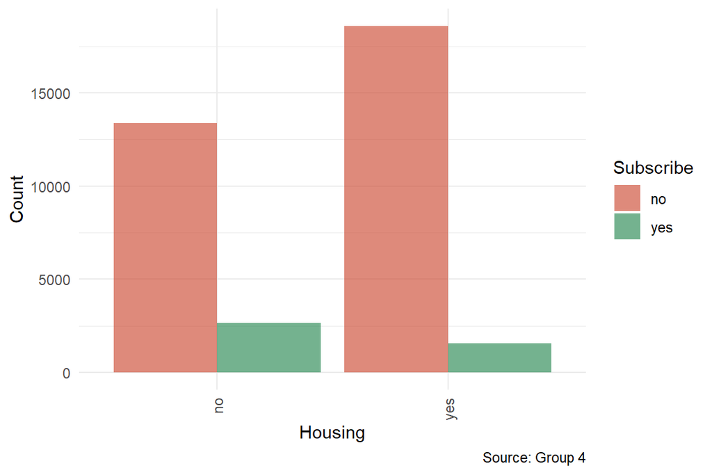

```r
# Using count
housing2 <- as.data.frame(table(bank_dataset[bank_dataset$train_test=="train",]$housing, bank_dataset[bank_dataset$train_test=="train",]$y))
colnames(housing2) <-  c("housing", "y", "count")

ggplot(data = housing2, aes(x = housing, y = count, fill = y)) +
  geom_bar(stat = 'identity', position = 'dodge', alpha = 2/3) +xlab("Housing")+
    ylab("Count") + theme_minimal() + theme(axis.text.x = element_text(angle = 90, hjust = 1, vjust = 0.5)) +
  scale_fill_manual(values = c("tomato3", "seagreen4")) + labs(fill = "Subscribe", caption = "Source: Group 4")
```